# **Introduction to Logistic Regression**

Logistic regression is a statistical method that is used for building machine learning models where the dependent variable is binary, multinomial or ordinal in nature.

Logistic regression is used to describe data and the relationship between one dependent variable and one or more independent variables.

The independent variables can be nominal, ordinal, or of interval type.

# **Logistic Regression intuition**

In statistics, the **Logistic Regression model** is a widely used statistical model which is primarily used for classification purposes.

It means that given a set of observations, Logistic Regression algorithm helps us to classify these observations into two or more discrete classes. So, the target variable is discrete in nature.

The Logistic Regression algorithm works as follows -

## **Implement linear equation**

Logistic Regression algorithm works by implementing a linear equation with independent or explanatory variables to predict a response value. For example, we consider the example of number of mock-test given and probability of passing the exam. Here, number of mock test given is the explanatory variable and it is denoted by x1. Probability of passing the exam is the response or target variable and it is denoted by z.

If we have one explanatory variable (x1) and one response variable (z), then the linear equation would be given mathematically with the following equation-

```
z = β0 + β1x1
```

Here, the coefficients β0 and β1 are the parameters of the model.

If there are multiple explanatory variables, then the above equation can be extended to

```
z = β0 + β1x1+ β2x2+……..+ βnxn
```

Here, the coefficients β0, β1, β2 and βn are the parameters of the model.

So, the predicted response value is given by the above equations and is denoted by z.

## **Sigmoid Function**

This predicted response value, denoted by z is then converted into a probability value that lie between 0 and 1. We use the sigmoid function in order to map predicted values to probability values. This sigmoid function then maps any real value into a probability value between 0 and 1.

In machine learning, sigmoid function is used to map predictions to probabilities. The sigmoid function has an S shaped curve. It is also called sigmoid curve.

Graphically, we can represent sigmoid function with the following graph.

### Sigmoid Function

[figure not shown]

## **Decision boundary**

The sigmoid function returns a probability value between 0 and 1. This probability value is then mapped to a discrete class which is either “0” or “1”. In order to map this probability value to a discrete class (pass/fail, yes/no, true/false), we select a threshold value. This threshold value is called Decision boundary. Above this threshold value, we will map the probability values into class 1 and below which we will map values into class 0.

Mathematically, it can be expressed as follows:-

p ≥ 0.5 => class = 1

p < 0.5 => class = 0

Generally, the decision boundary is set to 0.5. So, if the probability value is 0.8 (> 0.5), we will map this observation to class 1. Similarly, if the probability value is 0.2 (< 0.5), we will map this observation to class 0. This is represented in the graph below-

[figure not shown]

## **Making predictions**

Now, we know about sigmoid function and decision boundary in logistic regression. We can use our knowledge of sigmoid function and decision boundary to write a prediction function. A prediction function in logistic regression returns the probability of the observation being positive, Yes or True. We call this as class 1 and it is denoted by P(class = 1). If the probability inches closer to one, then we will be more confident about our model that the observation is in class 1, otherwise it is in class 0.

# **Assumptions of Logistic Regression**

The Logistic Regression model requires several key assumptions. These are as follows:-

1. Logistic Regression model requires the dependent variable to be binary, multinomial or ordinal in nature.
2. It requires the observations to be independent of each other. So, the observations should not come from repeated measurements.
3. Logistic Regression algorithm requires little or no multicollinearity among the independent variables. It means that the independent variables should not be too highly correlated with each other.
4. Logistic Regression model assumes linearity of independent variables and log odds.
5. The success of Logistic Regression model depends on the sample sizes. Typically, it requires a large sample size to achieve the high accuracy.

# **Types of Logistic Regression**

Logistic Regression model can be classified into three groups based on the target variable categories. These three groups are described below:-

### 1. Binary Logistic Regression

In Binary Logistic Regression, the target variable has two possible categories. The common examples of categories are yes or no, good or bad, true or false, spam or no spam and pass or fail.

### 2. Multinomial Logistic Regression

In Multinomial Logistic Regression, the target variable has three or more categories which are not in any particular order. So, there are three or more nominal categories. The examples include the type of categories of fruits - apple, mango, orange and banana.

### 3. Ordinal Logistic Regression

In Ordinal Logistic Regression, the target variable has three or more ordinal categories. So, there is intrinsic order involved with the categories. For example, the student performance can be categorized as poor, average, good and excellent.

# **Import libraries**

```python
from sklearn.datasets import make_classification #make_classification: available in sklearn.datasets and used to generate dataset
from matplotlib import pyplot as plt #matplotlib.pyplot: for plotting
from sklearn.linear_model import LogisticRegression #LogisticRegression: this is imported from sklearn.linear_model. Used for performing logistic regression
from sklearn.model_selection import train_test_split #train_test_split:imported from sklearn.model_selection and used to split dataset into training and test datasets
from sklearn.metrics import confusion_matrix #confusion matrix: imported from sklearn.metrics and used to generate the confusion matrix of the classifiers
import pandas as pd #Pandas for managing datasets.
```

# **Generate dataset**

To generate the dataset using the make_classification() function. We need to specify the number of samples, the number of feature, number of classes and other parameters.

```python
# Generate and dataset for Logistic Regression
z = x, y = make_classification(
    n_samples=100,
    n_features=1,
    n_classes=2,
    n_clusters_per_class=1,
    flip_y=0.03,
    n_informative=1,
    n_redundant=0,
    n_repeated=0
)
```

# **Visualize the data**

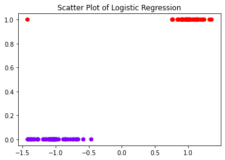

```python
# Create a scatter plot
plt.scatter(x, y, c=y, cmap='rainbow')
plt.title('Scatter Plot of Logistic Regression')
plt.show()
```

# **Split data into separate training and test set**

Split the dataset into training dataset and test dataset. The training dataset is used to train the model while the test dataset is used to test the model’s performance on new data.

```python
# Split the dataset into training and test dataset
x_train, x_test, y_train, y_test = train_test_split(x, y, random_state=1)
```

# **Model training**

Create a LogistiRegression object and fit it with out dataset.

```python
# Create a Logistic Regression Object, perform Logistic Regression
log_reg = LogisticRegression()
log_reg.fit(x_train, y_train)
```

```
LogisticRegression()
```

```python
# Show to Coeficient and Intercept
print(log_reg.coef_)
print(log_reg.intercept_)
```

```
[[2.79326292]]
[0.24729496]
```

# **Predict results**

Use the model to predict the outputs given the test dataset.

```python
# Perform prediction using the test dataset
y_pred = log_reg.predict(x_test)
```

# **Confusion matrix**

A confusion matrix is a tool for summarizing the performance of a classification algorithm. A confusion matrix will give us a clear picture of classification model performance and the types of errors produced by the model. It gives us a summary of correct and incorrect predictions broken down by each category. The summary is represented in a tabular form.

Four types of outcomes are possible while evaluating a classification model performance. These four outcomes are described below:-

**True Positives (TP)** – True Positives occur when we predict an observation belongs to a certain class and the observation actually belongs to that class.

**True Negatives (TN)** – True Negatives occur when we predict an observation does not belong to a certain class and the observation actually does not belong to that class.

**False Positives (FP)** – False Positives occur when we predict an observation belongs to a certain class but the observation actually does not belong to that class. This type of error is called **Type I error.**

**False Negatives (FN)** – False Negatives occur when we predict an observation does not belong to a certain class but the observation actually belongs to that class. This is a very serious error and it is called **Type II error.**

These four outcomes are summarized in a confusion matrix given below.

```python
# Show the Confusion Matrix
confusion_matrix(y_test, y_pred)
```

```
array([[14,  0],
       [ 0, 11]])
```